# stat475_A1

#### Q7

**In a study of insect physiology, eggs from a beneficial species of moth were put in boxes placed in chambers at different temperatures. There were 30 eggs placed into each box, and the number of eggs hatching after 30 days were counted. The first box at 10◦C had 0 hatch, the first box at 15◦C had 1 hatch, and the first box at 20◦C had 25 hatch. The data is courtesy of Jim Nechols, Department of Entomology, Kansas State University.**

##### a)Construct appropriate confidence intervals for the probability that an egg hatches at each temperature.

```r
library(binom)
C10 <- binom.confint(x=0,n=30,methods = "wilson")
C15 <- binom.confint(x=1,n=30,methods = "wilson")
C20<- binom.confint(x=25,n=30,methods = "wilson")
cbind(degree=c(10,15,20),rbind(C10,C15,C20))
```

| degree | method | x | n | mean | lower | upper |
| --- | --- | --- | --- | --- | --- | --- |
| 10 | wilson | 0 | 30 | 0.00000000 | 0.00000000 | 0.1135134 |
| 15 | wilson | 1 | 30 | 0.03333333 | 0.00590859 | 0.1667039 |
| 20 | wilson | 25 | 30 | 0.83333333 | 0.66435649 | 0.9266346 |

##### b)Assess informally whether the probabilities could be the same at each temperature. Explain your reasoning. Note that we will develop more formal ways of making these comparisons in Chapter 2.

The probability might be the same at 10 degree and 15 degree, because the  
the CI of 10 degree and 15 degree have partially overlap. The probability of  
20 degree is different from the other two.

#### Q8

**Continuing Exercise 7, the researchers actually used 10 different boxes of 30 eggs at each temperature. The counts of hatched eggs for the 10 boxes at 15◦C were 1, 2, 4, 1, 0, 0, 0, 12, 0, and 2.**

##### (a)

**Why do you suppose that the researchers used more than one box at each tem- perature?**

Because the experiment might be influenced by other uncontrollable additional  
factors, the results of multiple experiments are more accurate.

##### (b) Construct appropriate confidence intervals for the probability that an egg hatches in each box.

```r
hatched <- c(1,2,4,1,0,0,0,12,0,2)
cbind(box=c(1:10),binom.confint(hatched,n=30,methods = "wilson"))
```

|  | box | method | x | n | mean | lower | upper |
| --- | --- | --- | --- | --- | --- | --- | --- |
| 1 | 1 | wilson | 1 | 30 | 0.03333333 | 0.00590859 | 0.1667039 |
| 2 | 2 | wilson | 2 | 30 | 0.06666667 | 0.01847702 | 0.2132346 |
| 3 | 3 | wilson | 4 | 30 | 0.13333333 | 0.05309655 | 0.2968133 |
| 4 | 4 | wilson | 1 | 30 | 0.03333333 | 0.00590859 | 0.1667039 |
| 5 | 5 | wilson | 0 | 30 | 0.00000000 | 0.00000000 | 0.1135134 |
| 6 | 6 | wilson | 0 | 30 | 0.00000000 | 0.00000000 | 0.1135134 |
| 7 | 7 | wilson | 0 | 30 | 0.00000000 | 0.00000000 | 0.1135134 |
| 8 | 8 | wilson | 12 | 30 | 0.40000000 | 0.24590628 | 0.5767964 |
| 9 | 9 | wilson | 0 | 30 | 0.00000000 | 0.00000000 | 0.1135134 |
| 10 | 10 | wilson | 2 | 30 | 0.06666667 | 0.01847702 | 0.2132346 |

##### (c) Based on the intervals, does it appear that the probability that an egg hatches is the same in all boxes? Explain your reasoning.

No, they are different.The CI for box 8 which has 12 hatched egg only partially  
overlap with the CI for box 3 which has 4 hatched egg.

##### d)

**All 10 boxes were held in the same chamber at the same time, and the chamber was set to 15◦C. How do you suppose it could happen that they give such different counts? Hint: See part (c).**  
The condition of each box is not independant, and also the number of hached  
eggs might be influence by other factors. For example, the temprature in the chamber might be unevenly distrubuted. The box which near the heat source  
might has larger number of hatched eggs.

##### e)

**Do you think that it would be appropriate to consider the data as w = 22 successes coming from a binomial distribution with n = 300 trials? Why or why not?**  
No,the condition of each box are dependant. The probability of each box are  
not the same.

#### Q13

**There are many other proposed confidence intervals for π. One of these intervals mentioned in Section 1.1.2 was the LR interval. Using this interval, complete the following:**

##### a)

**Verify the 95% LR confidence interval is 0.1456 < π < 0.7000 when n = 10 and w = 4. Note that binom.confint() calculates this interval using the methods = “lrt” argument value. We also provide additional code to calculate the interval in CIpi.R.**

```r
binom.confint(x=4,n=10,methods = "lrt")
```

|  | method | x | n | mean | lower | upper |
| --- | --- | --- | --- | --- | --- | --- |
| 1 | lrt | 4 | 10 | 0.4 | 0.1456425 | 0.7000216 |

##### b)

**Construct a plot of the true confidence levels similar to those in Figure 1.3. Use n = 40 and α = 0.05, and vary π from 0.001 to 0.999 by 0.0005.**

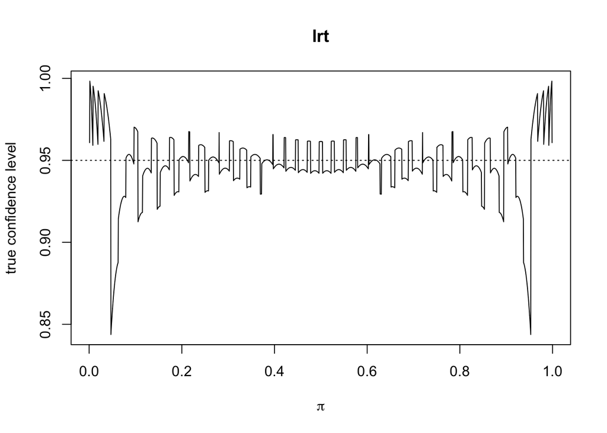

```r
n <- 40
alpha <- 0.05
x <- 0:n
PI <- seq(0.001,0.999,0.0005)
CI.true.plot <- function(n,alpha,x,PI,m){
  CI.true <- matrix(data=NA,n=length(PI),ncol = 1)
for (i in 1:length(PI)) {
  pi <- PI[i]
  pmf <- dbinom(x,n,prob=pi)
  intl <- binom.confint(x,n,methods = m)
  lower <- intl$lower
  upper <- intl$upper
  save <- ifelse(test= pi>lower,yes = ifelse(test = pi<upper,yes=1,no=0),no=0)
  CI.true[i] <- sum(pmf*save)
}
plot(x=PI,y=CI.true,type = "l",main = m ,ylab = "true confidence level",xlab = expression(pi))
abline(h = 0.95, lty ="dotted")
}
CI.true.plot(n,alpha,x,PI,"lrt")
```

##### c)

**Compare the LR interval’s true confidence level to those of the four other intervals discussed in Section 1.1.2. Which of these intervals is best? Explain.**

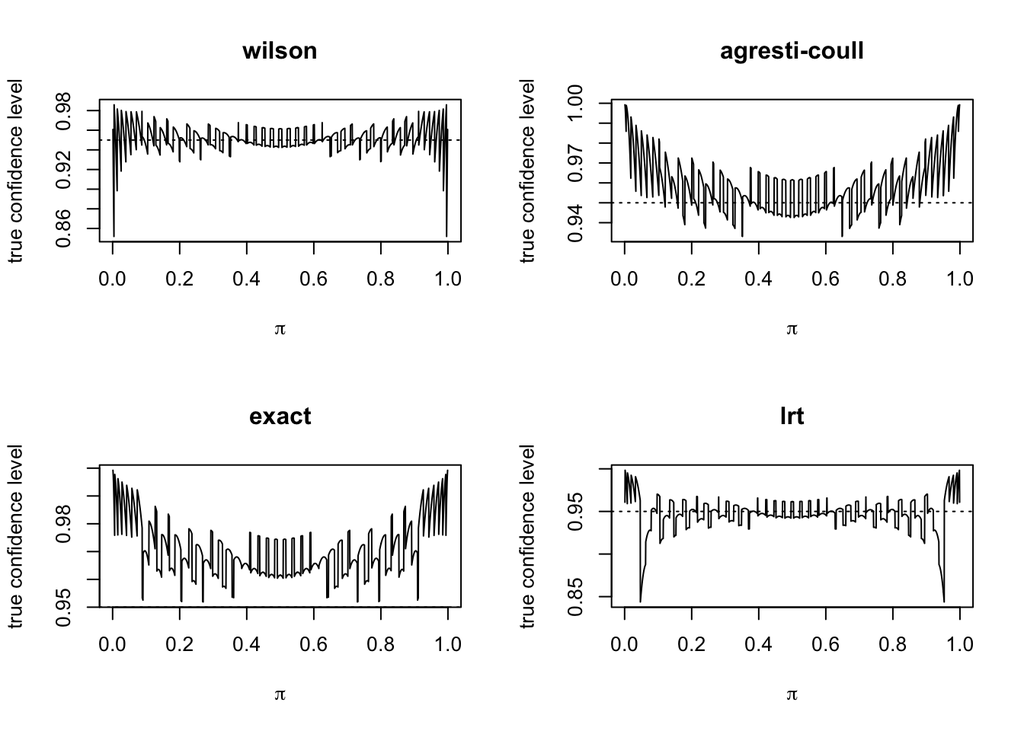

```r
par(mfrow=c(2,2))
CI.true.plot(n,alpha,x,PI,"wilson")
CI.true.plot(n,alpha,x,PI,"agresti-coull")
CI.true.plot(n,alpha,x,PI,"exact")
CI.true.plot(n,alpha,x,PI,"lrt")
```

Wilson confidence interval is the best.The true confidence level of LR interval  
generally around 0.95 which is similar to the Wilson interval. However, compare to  
the LRT method , the plot of Wilson interval looks like more stable. For Agresti-Coull  
method and Clopper-Pearson, they are more conservative than LR method.